# Used Cars Cleaning Notebook

This is the cleaning notebook for the used cars dataset. The dataset comes from kaggle: (‘https://www.kaggle.com/datasets/austinreese/craigslist-carstrucks-data’)

Once the dataset is thoroughly cleaned, an R Shiny dashboard will be created from the data.

```r
### load tidyverse library
library(tidyverse)

### read in data
df <- read_csv("vehicles.csv")
```

```r
### Check shape of the dataset
df %>% dim()
```

```
[1] 426880     26
```

The dataset has been sucessfully loaded and contains 426k rows and 26 columns of data

## Cleaning

- Explore the dataset and remove unwanted columns and Null values

```r
### Examine columns
df %>% colnames()
```

```
 [1] "id"           "url"          "region"       "region_url"   "price"        "year"         "manufacturer" "model"        "condition"    "cylinders"
[11] "fuel"         "odometer"     "title_status" "transmission" "VIN"          "drive"        "size"         "type"         "paint_color"  "image_url"
[21] "description"  "county"       "state"        "lat"          "long"         "posting_date"
```

```r
### Examine the first 5 rows that do not have any nulls in the column 'year'
df %>%
  filter(!is.na(year)) %>%
  head(5)
```

| id | url | region | region_url | price | year | manufacturer | model | condition | cylinders | fuel | odometer | title_status | transmission | VIN | drive | size | type | paint_color | image_url | description | county | state | lat | long | posting_date |
| --- | --- | --- | --- | --- | --- | --- | --- | --- | --- | --- | --- | --- | --- | --- | --- | --- | --- | --- | --- | --- | --- | --- | --- | --- | --- |
| 7316814884 | https://auburn.craigslist.org/ctd/d/auburn-university-2014-gmc-sierra-1500/7316814884.html | auburn | https://auburn.craigslist.org | 33590 | 2014 | gmc | sierra 1500 crew cab slt | good | 8 cylinders | gas | 57923 | clean | other | 3GTP1VEC4EG551563 | NA | NA | pickup | white | https://images.craigslist.org/00R0R_lwWjXSEWNa7z_0x20oM_600x450.jpg | Carvana is the safer way to buy a car During these uncertain times, Carvana is dedicated to ensuring safety for all of our customers. In addition to our 100% online shopping and selling experience tha… | NA | al | 32.590 | -85.4800 | 2021-05-04 17:31:18 |
| 7316814758 | https://auburn.craigslist.org/ctd/d/auburn-university-2010-chevy-chevrolet/7316814758.html | auburn | https://auburn.craigslist.org | 22590 | 2010 | chevrolet | silverado 1500 | good | 8 cylinders | gas | 71229 | clean | other | 1GCSCSE06AZ123805 | NA | NA | pickup | blue | https://images.craigslist.org/00R0R_lwWjXSEWNa7z_0x20oM_600x450.jpg | Carvana is the safer way to buy a car During these uncertain times, Carvana is dedicated to ensuring safety for all of our customers. In addition to our 100% online shopping and selling experience tha… | NA | al | 32.590 | -85.4800 | 2021-05-04 17:31:08 |
| 7316814989 | https://auburn.craigslist.org/ctd/d/auburn-university-2020-chevy-chevrolet/7316814989.html | auburn | https://auburn.craigslist.org | 39590 | 2020 | chevrolet | silverado 1500 crew | good | 8 cylinders | gas | 19160 | clean | other | 3GCPWCED5LG130317 | NA | NA | pickup | red | https://images.craigslist.org/01212_jjirIWa0y02z_0gw0co_600x450.jpg | Carvana is the safer way to buy a car During these uncertain times, Carvana is dedicated to ensuring safety for all of our customers. In addition to our 100% online shopping and selling experience tha… | NA | al | 32.590 | -85.4800 | 2021-05-04 17:31:25 |
| 7316743432 | https://auburn.craigslist.org/ctd/d/auburn-university-2017-toyota-tundra/7316743432.html | auburn | https://auburn.craigslist.org | 30990 | 2017 | toyota | tundra double cab sr | good | 8 cylinders | gas | 41124 | clean | other | 5TFRM5F17HX120972 | NA | NA | pickup | red | https://images.craigslist.org/00x0x_1y9kIOzGCFaz_0gw0co_600x450.jpg | Carvana is the safer way to buy a car During these uncertain times, Carvana is dedicated to ensuring safety for all of our customers. In addition to our 100% online shopping and selling experience tha… | NA | al | 32.590 | -85.4800 | 2021-05-04 15:41:31 |
| 7316356412 | https://auburn.craigslist.org/cto/d/auburn-university-2013-150/7316356412.html | auburn | https://auburn.craigslist.org | 15000 | 2013 | ford | f-150 xlt | excellent | 6 cylinders | gas | 128000 | clean | automatic | NA | rwd | full-size | truck | black | https://images.craigslist.org/00404_l4loxHvdQefz_0CI0t2_600x450.jpg | 2013 F-150 XLT V6 4 Door. Good condition. Leveling kit. New Tires. | NA | al | 32.592 | -85.5189 | 2021-05-03 19:02:03 |

Rows that we don’t need - url, region_url, VIN, image_url, description, lat, long, posting_date

Look into columns for missing values - drive, size, type

```r
### Examine the drive column and count
df <- df %>%
  select(-url, -region_url, -VIN, -image_url, -description, -lat, -long, -posting_date)
```

```r
### Examine the drive column and count
df %>%
  count(drive) %>%
  mutate(proportion = n / sum(n))
```

| drive | n | proportion |
| --- | --- | --- |
| 4wd | 131904 | 0.3089955 |
| fwd | 105517 | 0.2471819 |
| rwd | 58892 | 0.1379591 |
| NA | 130567 | 0.3058635 |

```r
NA
```

About 30% of these rows do not have a designated driving type, that is a large chunk of the data set, explore more and cut down on others and come back to this column and see what is left

```r
### Examine the drive column and count
df %>%
  count(size) %>%
  mutate(proportion = n / sum(n))
```

| size | n | proportion |
| --- | --- | --- |
| compact | 19384 | 0.045408546 |
| full-size | 63465 | 0.148671758 |
| mid-size | 34476 | 0.080762744 |
| sub-compact | 3194 | 0.007482196 |
| NA | 306361 | 0.717674756 |

```r
NA
```

70% of the data does not have a designated size - might just remove this column?

```r
### Examine the drive column and count
df %>%
  count(type) %>%
  mutate(proportion = n / sum(n))
```

| type | n | proportion |
| --- | --- | --- |
| SUV | 77284 | 0.181043853 |
| bus | 517 | 0.001211113 |
| convertible | 7731 | 0.018110476 |
| coupe | 19204 | 0.044986882 |
| hatchback | 16598 | 0.038882121 |
| mini-van | 4825 | 0.011302942 |
| offroad | 609 | 0.001426630 |
| other | 22110 | 0.051794415 |
| pickup | 43510 | 0.101925600 |
| sedan | 87056 | 0.203935532 |

[output cut: 4 more lines]

```r
NA
```

```r
### Examine columns
df %>% colnames()
```

```
 [1] "id"           "region"       "price"        "year"         "manufacturer" "model"        "condition"    "cylinders"    "fuel"         "odometer"
[11] "title_status" "transmission" "drive"        "size"         "type"         "paint_color"  "county"       "state"
```

I want to keep all of these columns if i can reliably fill the missing data - go through each column and remove rows - once done, do another check for missing data

```r
### Examine columns
df %>%
  summarise_all(~ sum(is.na(.))) %>%
  pivot_longer(cols = everything(), names_to = "Column", values_to = "NA_Count") %>%
  mutate(Proportion = NA_Count / nrow(df))
```

| Column | NA_Count | Proportion |
| --- | --- | --- |
| id | 0 | 0.000000000 |
| region | 0 | 0.000000000 |
| price | 0 | 0.000000000 |
| year | 1205 | 0.002822807 |
| manufacturer | 17646 | 0.041337144 |
| model | 5276 | 0.012359445 |
| condition | 174104 | 0.407852324 |
| cylinders | 177678 | 0.416224700 |
| fuel | 3013 | 0.007058190 |
| odometer | 4400 | 0.010307346 |

[output cut: 8 more lines]

### Year Column

```r
### Examine columns
df['year'] %>% summary()
```

```
      year
 Min.   :1900
 1st Qu.:2008
 Median :2013
 Mean   :2011
 3rd Qu.:2017
 Max.   :2022
 NAs    :1205
```

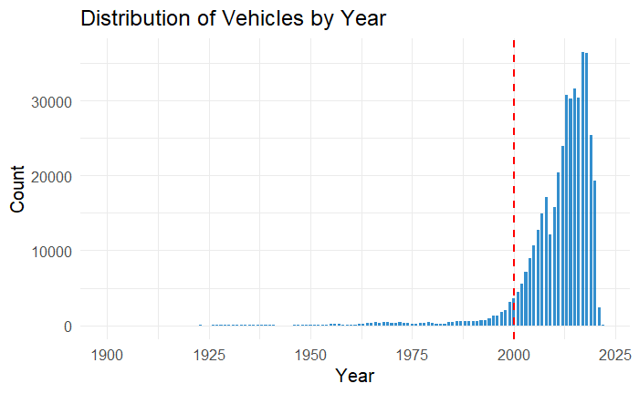

```r
### Examine distribution of year column
df %>%
  count(year) %>%
  mutate(proportion = n / sum(n)) %>%
  ggplot(aes(x = year, y = n)) +
  geom_col(fill = "#0073C2FF", alpha = 0.8, width = 0.7) +
  geom_vline(xintercept = 2000, color = "red", linetype = "dashed", size = 1) +
  labs(
    title = "Distribution of Vehicles by Year",
    x = "Year",
    y = "Count"
  ) +
  theme_minimal(base_size = 15)
```

Remove data from before 2000? - most cars being sold are in the range of 2008-2017

```r
### Examine distribution of year column
df <- df %>%
  filter(year >= 2000)
```

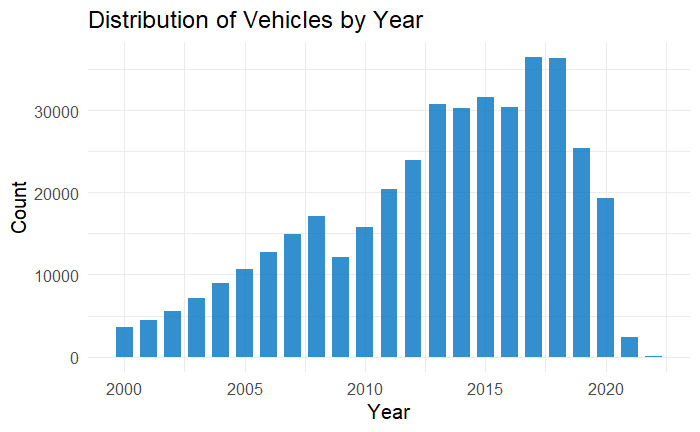

```r
### Examine distribution of year column
df %>%
  count(year) %>%
  mutate(proportion = n / sum(n)) %>%
  ggplot(aes(x = year, y = n)) +
  geom_col(fill = "#0073C2FF", alpha = 0.8, width = 0.7)+
  labs(
    title = "Distribution of Vehicles by Year",
    x = "Year",
    y = "Count"
  ) +
  theme_minimal(base_size = 15)
```

### Price Column

Clean Price Column

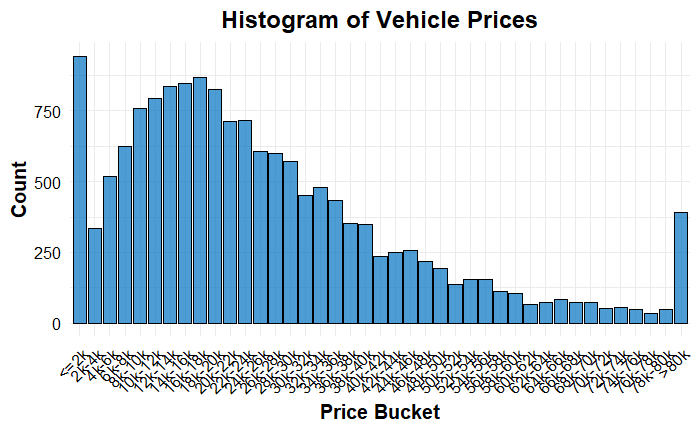

```r
### Examine distribution of the  price column
df %>%
  count(price) %>%
  mutate(price_bucket = cut(
    price,
    breaks = c(-Inf, seq(2000, 80000, by = 2000), Inf),
    labels = c("<=2k", paste(seq(2, 78, by = 2), "k-", seq(4, 80, by = 2), "k", sep = ""), ">80k"),
    right = TRUE
  )) %>%
  ggplot(aes(x = price_bucket)) +
  geom_bar(fill = "#0073C2FF", color = "black", alpha = 0.7) +
  labs(
    title = "Histogram of Vehicle Prices",
    x = "Price Bucket",
    y = "Count"
  ) +
  theme_minimal(base_size = 15) +
  theme(
    plot.title = element_text(face = "bold", hjust = 0.5),
    axis.text.x = element_text(angle = 45, hjust = 1),
    axis.text = element_text(color = "black"),
    axis.title = element_text(face = "bold")
  ) +
  scale_x_discrete(drop = FALSE)
```

```r
### Examine distribution of year column
df %>%
  mutate(price_bucket = cut(
    price,
    breaks = c(-Inf, seq(2000, 80000, by = 2000), Inf),
    labels = c("<=2k", paste(seq(2, 78, by = 2), "k-", seq(4, 80, by = 2), "k", sep = ""), ">80k"),
    right = TRUE
  )) %>%
  count(price_bucket) %>%
  mutate(proportion = n / sum(n)*100)
```

| price_bucket | n | proportion |
| --- | --- | --- |
| <=2k | 50739 | 12.67128676 |
| 2k-4k | 21702 | 5.41974152 |
| 4k-6k | 30377 | 7.58618967 |
| 6k-8k | 30781 | 7.68708247 |
| 8k-10k | 26447 | 6.60473247 |
| 10k-12k | 20264 | 5.06062309 |
| 12k-14k | 19624 | 4.90079291 |
| 14k-16k | 20422 | 5.10008116 |
| 16k-18k | 18901 | 4.72023475 |
| 18k-20k | 17811 | 4.44802397 |

[output cut: 31 more lines]

```r
NA
```

```r
### Examine distribution of year column
df <- df %>%
  filter(price < 80000)
```

check the price column again - use increments of 500

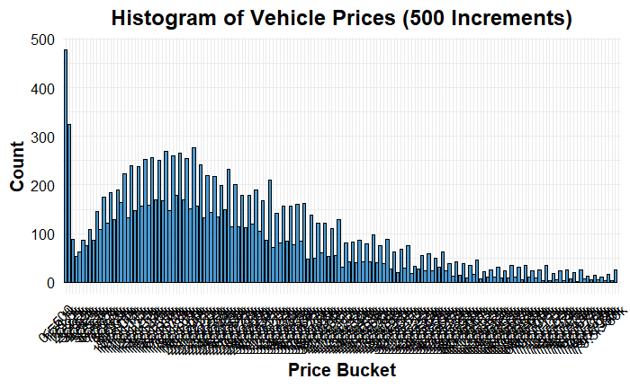

```r
### Examine distribution of the  price column
df %>%
  count(price) %>%
  mutate(price_bucket = cut(
    price,
    breaks = c(-Inf, seq(500, 80000, by = 500), Inf),
    labels = c("<=500", paste(seq(0.5, 79.5, by = 0.5), "k-", seq(1, 80, by = 0.5), "k", sep = ""), ">80k"),
    right = TRUE
  )) %>%
  ggplot(aes(x = price_bucket)) +
  geom_bar(fill = "#0073C2FF", color = "black", alpha = 0.7) +
  labs(
    title = "Histogram of Vehicle Prices (500 Increments)",
    x = "Price Bucket",
    y = "Count"
  ) +
  theme_minimal(base_size = 15) +
  theme(
    plot.title = element_text(face = "bold", hjust = 0.5),
    axis.text.x = element_text(angle = 45, hjust = 1),
    axis.text = element_text(color = "black"),
    axis.title = element_text(face = "bold")
  ) +
  scale_x_discrete(drop = FALSE)
```

```r
### Examine distribution of year column
df %>%
  mutate(price_bucket = cut(
    price,
    breaks = c(-Inf, seq(500, 80000, by = 500), Inf),
    labels = c("<=500", paste(seq(0.5, 79.5, by = 0.5), "k-", seq(1, 80, by = 0.5), "k", sep = ""), ">80k"),
    right = TRUE
  )) %>%
  count(price_bucket) %>%
  mutate(proportion = n / sum(n)*100)
```

| price_bucket | n | proportion |
| --- | --- | --- |
| <=500 | 42000 | 10.525814560 |
| 0.5k-1k | 3714 | 0.930782745 |
| 1k-1.5k | 2169 | 0.543583138 |
| 1.5k-2k | 2856 | 0.715755390 |
| 2k-2.5k | 3455 | 0.865873555 |
| 2.5k-3k | 5401 | 1.353569630 |
| 3k-3.5k | 5063 | 1.268861884 |
| 3.5k-4k | 7783 | 1.950533684 |
| 4k-4.5k | 5836 | 1.462586995 |
| 4.5k-5k | 9057 | 2.269816726 |

[output cut: 150 more lines]

```r
NA
```

```r
### Examine distribution of year column
df <- df %>%
  filter(price > 1000)
```

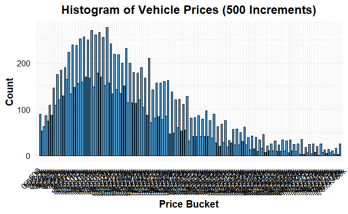

```r
### Examine distribution of the  price column
df %>%
  count(price) %>%
  mutate(price_bucket = cut(
    price,
    breaks = c(-Inf, seq(500, 80000, by = 500), Inf),
    labels = c("<=500", paste(seq(0.5, 79.5, by = 0.5), "k-", seq(1, 80, by = 0.5), "k", sep = ""), ">80k"),
    right = TRUE
  )) %>%
  ggplot(aes(x = price_bucket)) +
  geom_bar(fill = "#0073C2FF", color = "black", alpha = 0.7) +
  labs(
    title = "Histogram of Vehicle Prices (500 Increments)",
    x = "Price Bucket",
    y = "Count"
  ) +
  theme_minimal(base_size = 15) +
  theme(
    plot.title = element_text(face = "bold", hjust = 0.5),
    axis.text.x = element_text(angle = 45, hjust = 1),
    axis.text = element_text(color = "black"),
    axis.title = element_text(face = "bold")
  ) +
  scale_x_discrete(drop = FALSE)
```

ok this looks good to me, i guess…

### Region Column

```r
### Examine the drive column and count
df %>%
  count(region) %>%
  mutate(proportion = n / sum(n))
```

| region | n | proportion |
| --- | --- | --- |
| SF bay area | 2313 | 6.546751e-03 |
| abilene | 204 | 5.774048e-04 |
| akron / canton | 1965 | 5.561767e-03 |
| albany | 2266 | 6.413722e-03 |
| albuquerque | 2150 | 6.085394e-03 |
| altoona-johnstown | 311 | 8.802593e-04 |
| amarillo | 529 | 1.497290e-03 |
| ames | 180 | 5.094748e-04 |
| anchorage / mat-su | 2555 | 7.231712e-03 |
| ann arbor | 946 | 2.677573e-03 |

[output cut: 394 more lines]

```r
NA
```

There are too many regions, they span different cities and subdivisions in the USA - if i were to keep this column it would be too many variables to account for. - i am going to drop this column

```r
### Examine the drive column and count
df %>%
  select(-region)
```

| id | price | year | manufacturer | model | condition | cylinders | fuel | odometer | title_status | transmission | drive | size | type | paint_color | county | state |
| --- | --- | --- | --- | --- | --- | --- | --- | --- | --- | --- | --- | --- | --- | --- | --- | --- |
| 7316814884 | 33590 | 2014 | gmc | sierra 1500 crew cab slt | good | 8 cylinders | gas | 57923 | clean | other | NA | NA | pickup | white | NA | al |
| 7316814758 | 22590 | 2010 | chevrolet | silverado 1500 | good | 8 cylinders | gas | 71229 | clean | other | NA | NA | pickup | blue | NA | al |
| 7316814989 | 39590 | 2020 | chevrolet | silverado 1500 crew | good | 8 cylinders | gas | 19160 | clean | other | NA | NA | pickup | red | NA | al |
| 7316743432 | 30990 | 2017 | toyota | tundra double cab sr | good | 8 cylinders | gas | 41124 | clean | other | NA | NA | pickup | red | NA | al |
| 7316356412 | 15000 | 2013 | ford | f-150 xlt | excellent | 6 cylinders | gas | 128000 | clean | automatic | rwd | full-size | truck | black | NA | al |
| 7316343444 | 27990 | 2012 | gmc | sierra 2500 hd extended cab | good | 8 cylinders | gas | 68696 | clean | other | 4wd | NA | pickup | black | NA | al |
| 7316304717 | 34590 | 2016 | chevrolet | silverado 1500 double | good | 6 cylinders | gas | 29499 | clean | other | 4wd | NA | pickup | silver | NA | al |
| 7316285779 | 35000 | 2019 | toyota | tacoma | excellent | 6 cylinders | gas | 43000 | clean | automatic | 4wd | NA | truck | grey | NA | al |
| 7316257769 | 29990 | 2016 | chevrolet | colorado extended cab | good | 6 cylinders | gas | 17302 | clean | other | 4wd | NA | pickup | red | NA | al |
| 7316133914 | 38590 | 2011 | chevrolet | corvette grand sport | good | 8 cylinders | gas | 30237 | clean | other | rwd | NA | other | red | NA | al |

[output cut: 990 more lines]

```r
NA
```

### manufacturer Column

```r
### Examine the drive column and count
df %>%
  count(manufacturer) %>%
  mutate(proportion = n / sum(n))
```

| manufacturer | n | proportion |
| --- | --- | --- |
| acura | 5446 | 1.541444e-02 |
| alfa-romeo | 828 | 2.343584e-03 |
| aston-martin | 16 | 4.528665e-05 |
| audi | 6908 | 1.955251e-02 |
| bmw | 12885 | 3.646991e-02 |
| buick | 4647 | 1.315294e-02 |
| cadillac | 5860 | 1.658624e-02 |
| chevrolet | 43795 | 1.239581e-01 |
| chrysler | 5249 | 1.485685e-02 |
| dodge | 10773 | 3.049207e-02 |

[output cut: 32 more lines]

```r
NA
```

This is an important column to keep, i need to remove cars without a manufacturer and also remove manufacturers in which we don’t have many observations with (<1000) - aston-martin 16 - alfa-romeo 828 - ferrari 3 - fiat 700 - harley-davidson 124 - land rover 9 - morgan 1 - mercury 773 - tesla 799 - saturn 984 - NA

```r
### drop manufacturers with small sample size

# Define the list of manufacturers to filter
low_manufacturers <- c("aston-martin", "ferrari", "harley-davidson",
                            "land rover", "morgan", "mercury", "tesla", "saturn", 'fiat', 'alfa-romeo')

# Filter the data to exclude the selected manufacturers and NA values
df <- df %>%
  filter(!(manufacturer %in% low_manufacturers) & !is.na(manufacturer))
```

```r
### check
df %>%
  count(manufacturer) %>%
  mutate(proportion = n / sum(n))
```

| manufacturer | n | proportion |
| --- | --- | --- |
| acura | 5446 | 0.016084350 |
| audi | 6908 | 0.020402256 |
| bmw | 12885 | 0.038054875 |
| buick | 4647 | 0.013724564 |
| cadillac | 5860 | 0.017307068 |
| chevrolet | 43795 | 0.129345226 |
| chrysler | 5249 | 0.015502525 |
| dodge | 10773 | 0.031817242 |
| ford | 58057 | 0.171466966 |
| gmc | 14118 | 0.041696447 |

[output cut: 21 more lines]

```r
NA
NA
```

i am good with this

### model Column

```r
### Examine the drive column and count
df %>%
  count(model) %>%
  mutate(proportion = n / sum(n)) %>%
  arrange(desc(proportion))
```

| model | n | proportion |
| --- | --- | --- |
| f-150 | 6588 | 0.0194571606 |
| silverado 1500 | 4251 | 0.0125550075 |
| 1500 | 3498 | 0.0103310789 |
| NA | 2741 | 0.0080953365 |
| camry | 2532 | 0.0074780708 |
| accord | 2447 | 0.0072270297 |
| escape | 2444 | 0.0072181695 |
| silverado | 2444 | 0.0072181695 |
| civic | 2391 | 0.0070616380 |
| altima | 2242 | 0.0066215777 |

[output cut: 990 more lines]

```r
NA
```

this column has too many variables, i will drop it. there is a type column that indicates general models like ‘sedan’ or ‘coupe’ which might be enough

### condition Column

```r
### Examine the condition column and count
df %>%
  count(condition) %>%
  mutate(proportion = n / sum(n)) %>%
  arrange(desc(proportion))
```

| condition | n | proportion |
| --- | --- | --- |
| NA | 130513 | 0.3854602912 |
| good | 104342 | 0.3081662187 |
| excellent | 82028 | 0.2422635045 |
| like new | 17241 | 0.0509199917 |
| fair | 3381 | 0.0099855282 |
| new | 789 | 0.0023302519 |
| salvage | 296 | 0.0008742137 |

```r
NA
```

38% of cars have missing data in this column - ill designate these as ‘fair’

remove the rows with salvage and new - there is not enough data

replace ‘like new’ with excellent

```r
# Remove rows with 'new' or 'salvage' in 'condition' and replace NAs with 'fair'
df <- df %>%
  filter(!(condition %in% c("new", "salvage"))) %>%
  mutate(
    condition = replace_na(condition, "fair"),
    condition = if_else(condition == "like new", "excellent", condition)
  )
```

```r
### Examine the condition column and count
df %>%
  count(condition) %>%
  mutate(proportion = n / sum(n)) %>%
  arrange(desc(proportion))
```

| condition | n | proportion |
| --- | --- | --- |
| fair | 133894 | 0.3967171 |
| good | 104342 | 0.3091569 |
| excellent | 99269 | 0.2941260 |

```r
NA
```

looks good

### cylinders Column

```r
### Examine the cylinders column and count
df %>%
  count(cylinders) %>%
  mutate(proportion = n / sum(n)) %>%
  arrange(desc(proportion))
```

| cylinders | n | proportion |
| --- | --- | --- |
| NA | 139473 | 0.4132472112 |
| 6 cylinders | 77951 | 0.2309625043 |
| 4 cylinders | 63136 | 0.1870668583 |
| 8 cylinders | 53460 | 0.1583976534 |
| 5 cylinders | 1397 | 0.0041391979 |
| 10 cylinders | 991 | 0.0029362528 |
| other | 624 | 0.0018488615 |
| 3 cylinders | 418 | 0.0012385002 |
| 12 cylinders | 55 | 0.0001629605 |

```r
NA
```

check whats going on in 3,5,10,12, etc

```r
# check na values
df %>%
  filter(is.na(cylinders))
```

| id | region | price | year | manufacturer | model | condition | cylinders | fuel | odometer | title_status | transmission | drive | size | type | paint_color | county | state |
| --- | --- | --- | --- | --- | --- | --- | --- | --- | --- | --- | --- | --- | --- | --- | --- | --- | --- |
| 7315756348 | auburn | 30990 | 2016 | chevrolet | colorado crew cab z71 | good | NA | other | 34940 | clean | other | 4wd | NA | pickup | blue | NA | al |
| 7315715960 | auburn | 27990 | 2014 | toyota | tacoma access cab pickup | good | NA | other | 17805 | clean | other | NA | NA | pickup | red | NA | al |
| 7315275975 | auburn | 33590 | 2014 | toyota | tundra crewmax sr5 pickup | good | NA | other | 55251 | clean | other | NA | NA | pickup | red | NA | al |
| 7315275942 | auburn | 30990 | 2019 | ford | ranger supercrew xl pickup | good | NA | other | 1834 | clean | other | NA | NA | pickup | black | NA | al |
| 7314854462 | auburn | 30590 | 2016 | toyota | tacoma double cab sr5 | good | NA | other | 30176 | clean | other | NA | NA | pickup | red | NA | al |
| 7314811916 | auburn | 32990 | 2020 | jeep | wrangler sport suv 2d | good | NA | gas | 20581 | clean | other | 4wd | NA | SUV | silver | NA | al |
| 7314584315 | auburn | 31590 | 2020 | mazda | mx-5 miata club | good | NA | gas | 2195 | clean | other | rwd | NA | other | NA | NA | al |
| 7314584322 | auburn | 27990 | 2020 | ford | ranger supercab xl pickup | good | NA | gas | 10688 | clean | other | NA | NA | pickup | white | NA | al |
| 7314584291 | auburn | 31590 | 2019 | cadillac | xt4 sport suv 4d | good | NA | other | 12102 | clean | other | fwd | NA | hatchback | black | NA | al |
| 7313857831 | auburn | 16590 | 2016 | jeep | renegade sport suv 4d | good | NA | gas | 35835 | clean | other | 4wd | NA | other | red | NA | al |

[output cut: 990 more lines]

```r
NA
```

```r
# check odd cylinder values
df %>%
  filter((cylinders %in% c("3 cylinders", "5 cylinders", "12 cylinders", "10 cylinders", "other")))
```

| id | region | price | year | manufacturer | model | condition | cylinders | fuel | odometer | title_status | transmission | drive | size | type | paint_color | county | state |
| --- | --- | --- | --- | --- | --- | --- | --- | --- | --- | --- | --- | --- | --- | --- | --- | --- | --- |
| 7316871204 | birmingham | 6995 | 2011 | volkswagen | jetta sel | excellent | 5 cylinders | gas | 172752 | clean | automatic | fwd | NA | sedan | black | NA | al |
| 7315518205 | birmingham | 3999 | 2009 | volvo | s60 | fair | 5 cylinders | gas | 182005 | clean | automatic | fwd | NA | sedan | silver | NA | al |
| 7314334186 | birmingham | 6950 | 2011 | volkswagen | jetta | excellent | 5 cylinders | gas | 116000 | clean | automatic | fwd | full-size | sedan | silver | NA | al |
| 7312358654 | birmingham | 3999 | 2009 | volvo | s60 | fair | 5 cylinders | gas | 182005 | clean | automatic | fwd | NA | NA | silver | NA | al |
| 7311390113 | birmingham | 24990 | 2007 | ford | super duty f-450 drw | good | 10 cylinders | gas | 46463 | clean | automatic | rwd | full-size | truck | white | NA | al |
| 7311387508 | birmingham | 22990 | 2010 | ford | econoline commercial cutaway | good | 10 cylinders | gas | 121911 | clean | automatic | rwd | full-size | truck | white | NA | al |
| 7311383356 | birmingham | 30990 | 2014 | ford | econoline commercial cutaway | good | 10 cylinders | gas | 98123 | clean | automatic | rwd | NA | NA | white | NA | al |
| 7311383252 | birmingham | 35990 | 2014 | ford | super duty f-450 drw | good | 10 cylinders | gas | 42213 | clean | automatic | 4wd | full-size | truck | white | NA | al |
| 7311381690 | birmingham | 24990 | 2007 | ford | super duty f-450 drw | good | 10 cylinders | gas | 46463 | clean | automatic | rwd | full-size | truck | white | NA | al |
| 7311381692 | birmingham | 22990 | 2010 | ford | econoline commercial cutaway | good | 10 cylinders | gas | 121911 | clean | automatic | rwd | full-size | truck | white | NA | al |

[output cut: 990 more lines]

```r
NA
```

Yeah there is a lot of stuff missing here. some car makes will have different cylinders based on the specific model - probably drop these. since cylinders are a good indicator of price - can also drop the other odd cylinder values. only ~3k rows dropped from these

```r
# remove rows with odd cylinders and NAs
df <- df %>%
  drop_na(cylinders) %>%
  filter(!(cylinders %in% c("3 cylinders", "5 cylinders", "12 cylinders", "10 cylinders", "other")))
```

```r
### Examine the cylinders column and count
df %>%
  count(cylinders) %>%
  mutate(proportion = n / sum(n)) %>%
  arrange(desc(proportion))
```

| cylinders | n | proportion |
| --- | --- | --- |
| 6 cylinders | 77951 | 0.4006795 |
| 4 cylinders | 63136 | 0.3245283 |
| 8 cylinders | 53460 | 0.2747922 |

```r
NA
```

looks good

### fuel column

```r
### Examine the cylinders column and count
df %>%
  count(fuel) %>%
  mutate(proportion = n / sum(n)) %>%
  arrange(desc(proportion))
```

| fuel | n | proportion |
| --- | --- | --- |
| gas | 174577 | 0.8973512827 |
| diesel | 10936 | 0.0562126376 |
| other | 5259 | 0.0270320283 |
| hybrid | 2600 | 0.0133643798 |
| NA | 1076 | 0.0055307972 |
| electric | 99 | 0.0005088745 |

```r
NA
```

most are gas vehicles, some are NA, some are other. i dont know what that means. lets check it out

[output cut: 990 more lines]

```r
# Remove rows with 'new' or 'salvage' in 'condition' and replace NAs with 'fair'
df %>%
  filter(is.na(fuel))
```

| id | region | price | year | manufacturer | model | condition | cylinders | fuel | odometer | title_status | transmission | drive | size | type | paint_color | county | state |
| --- | --- | --- | --- | --- | --- | --- | --- | --- | --- | --- | --- | --- | --- | --- | --- | --- | --- |
| 7316396026 | birmingham | 20995 | 2011 | chevrolet | silverado 1500 ltz crew cab 4wd | fair | NA | NA | 137701 | NA | automatic | 4wd | NA | pickup | NA | NA | al |
| 7316395026 | birmingham | 25995 | 2015 | chevrolet | silverado 1500 lt crew cab 4wd | fair | NA | NA | 151681 | NA | automatic | 4wd | NA | pickup | NA | NA | al |
| 7316393935 | birmingham | 31995 | 2014 | chevrolet | silverado 1500 2lt crew cab long box 4wd | fair | NA | NA | 66738 | NA | automatic | 4wd | NA | pickup | NA | NA | al |
| 7315518138 | birmingham | 8980 | 2011 | jeep | grand cherokee | fair | 6 cylinders | NA | 173787 | NA | manual | rwd | NA | SUV | silver | NA | al |
| 7314945978 | birmingham | 3350 | 2010 | chevrolet | hhr | fair | 4 cylinders | NA | 177602 | clean | automatic | rwd | NA | SUV | red | NA | al |
| 7314709451 | birmingham | 31990 | 2016 | chevrolet | silverado 1500 | fair | 8 cylinders | NA | 107597 | clean | automatic | 4wd | NA | pickup | white | NA | al |
| 7313727515 | birmingham | 25500 | 2015 | jaguar | xj | fair | 6 cylinders | NA | 71114 | clean | automatic | rwd | NA | sedan | black | NA | al |
| 7312471541 | birmingham | 5980 | 2008 | chevrolet | impala | fair | 6 cylinders | NA | 165596 | NA | automatic | fwd | NA | sedan | black | NA | al |
| 7312431442 | birmingham | 3450 | 2007 | toyota | prius | fair | 4 cylinders | NA | 263198 | clean | automatic | fwd | NA | NA | grey | NA | al |
| 7312402472 | birmingham | 7980 | 2008 | nissan | titan | fair | 8 cylinders | NA | 200850 | NA | automatic | rwd | NA | pickup | white | NA | al |

[output cut: 990 more lines]

```r
NA
```